# PeHa data check

Michelle DePrenger-Levin

Thursday, September 10, 2015

```r
library(ggplot2)
library(reshape2)
library(grid)
library(devtools)
library(lattice)
```

ctrl+Alt+c will run a chunck of code

gather climate data from WWDT and/or http://www.prism.oregonstate.edu/explorer/  
Make sure to set the resolution to 800m and the Units to SI (metric)!!  
First 6 lines of code are metadata  
first column is YYYY-MM and then data in metric

```
    Latitude/Longitude      Y           X           Site
    39.6917°N, 106.9598°W   4395377.218 331953.342  Dry Lake
    39.6547°N, 106.7843°W   4390957.204 346919.7342 Above Eagle
```

#### Climate data

```r
ae_p <- read.csv(path.expand("Q:/Research/All_Projects_by_Species/Penstemon SPECIES/Penstemon_harringtonii/R_code_PeHa/R_tables/AE_precip_2015.csv"), skip=6)
dl_p <- read.csv(path.expand("Q:/Research/All_Projects_by_Species/Penstemon SPECIES/Penstemon_harringtonii/R_code_PeHa/R_tables/DL_precip_2015.csv"), skip=6)
ae_tmax <- read.csv(path.expand("Q:/Research/All_Projects_by_Species/Penstemon SPECIES/Penstemon_harringtonii/R_code_PeHa/R_tables/AE_tmax_2015.csv"), skip=6)
dl_tmax <- read.csv(path.expand("Q:/Research/All_Projects_by_Species/Penstemon SPECIES/Penstemon_harringtonii/R_code_PeHa/R_tables/DL_maxtemp_2015.csv"), skip=6)
ae_tmin <- read.csv(path.expand("Q:/Research/All_Projects_by_Species/Penstemon SPECIES/Penstemon_harringtonii/R_code_PeHa/R_tables/AE_tmin_2015.csv"), skip=6)
dl_tmin <- read.csv(path.expand("Q:/Research/All_Projects_by_Species/Penstemon SPECIES/Penstemon_harringtonii/R_code_PeHa/R_tables/DL_tmin_2015.csv"), skip=6)

ae.climate <- data.frame(ae_p,ae_tmax,ae_tmin)
ae.climate$Site <- "Above Eagle"

dl.climate <- data.frame(dl_p,dl_tmax,dl_tmin)
dl.climate$Site <- "Dry Lake"

peha.climate <- rbind(ae.climate,dl.climate)
peha.climate$Year <- substr(ae.climate$Date,1,4)
peha.climate$Month <- substr(ae.climate$Date,6,7)

head(peha.climate)
```

```
##      Date ppt..mm.  Date.1 tmax..degrees.C.  Date.2 tmin..degrees.C.
## 1 1995-07    59.37 1995-07             26.3 1995-07              6.8
## 2 1995-08    30.61 1995-08             28.7 1995-08              8.5
## 3 1995-09    40.44 1995-09             23.0 1995-09              3.6
## 4 1995-10    28.17 1995-10             15.1 1995-10             -4.0
## 5 1995-11    43.06 1995-11              8.7 1995-11             -5.8
## 6 1995-12    34.44 1995-12              3.1 1995-12            -11.7
##          Site Year Month
## 1 Above Eagle 1995    07
## 2 Above Eagle 1995    08
## 3 Above Eagle 1995    09
## 4 Above Eagle 1995    10
## 5 Above Eagle 1995    11
## 6 Above Eagle 1995    12
```

```r
peha.c <- peha.climate[,c(1,2,4,6:9)]
names(peha.c) <- c("Date","Precip","Tmax","Tmin","Site","Year","Month")
peha.c$Date <- as.Date(paste(peha.climate$Date,"01", sep="-")) # needs the day
```

```r
peha_summary <- read.csv(path.expand("Q:/Research/All_Projects_by_Species/Penstemon SPECIES/Penstemon_harringtonii/R_code_PeHa/R_tables/peha_2015_summary.csv"))
```

```r
peha <- read.csv(path.expand("Q:/Research/All_Projects_by_Species/Penstemon SPECIES/Penstemon_harringtonii/R_code_PeHa/R_tables/peha2015.csv"))

head(peha)
```

```
##          Site Year Transect     X    Y X.ofRosettes Fl Fr_Fl Br Comments
## 1 Above Eagle 1996        2 17.16 0.79            2  0     0  0
## 2 Above Eagle 1996        2 33.73 0.78            1  0     0  0
## 3 Above Eagle 1996        2 57.69 0.50            1  1     0  0
## 4 Above Eagle 1996        2  9.17 0.75            1  0     0  0
## 5 Above Eagle 1996        2 21.27 0.60            2  0     0  0      fly
## 6 Above Eagle 1996        2 55.52 0.75            1  0     0  0
```

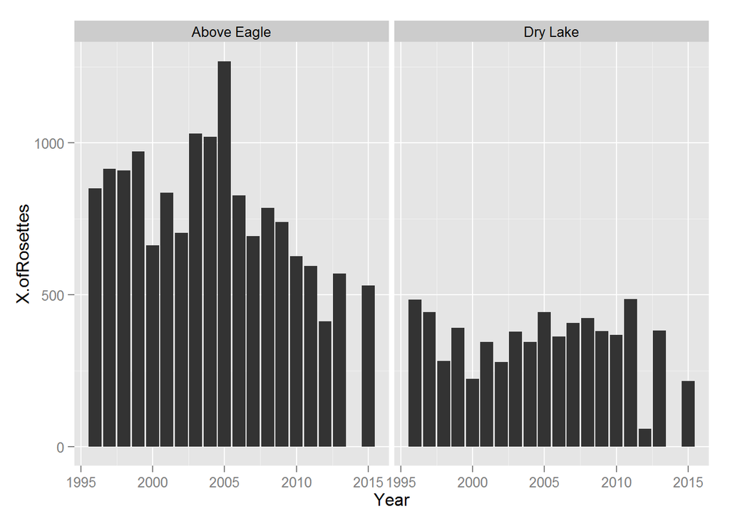

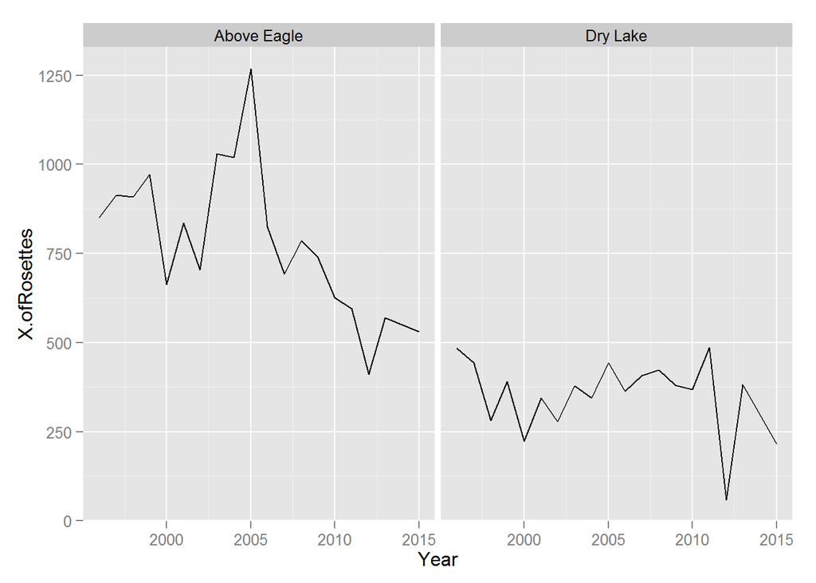

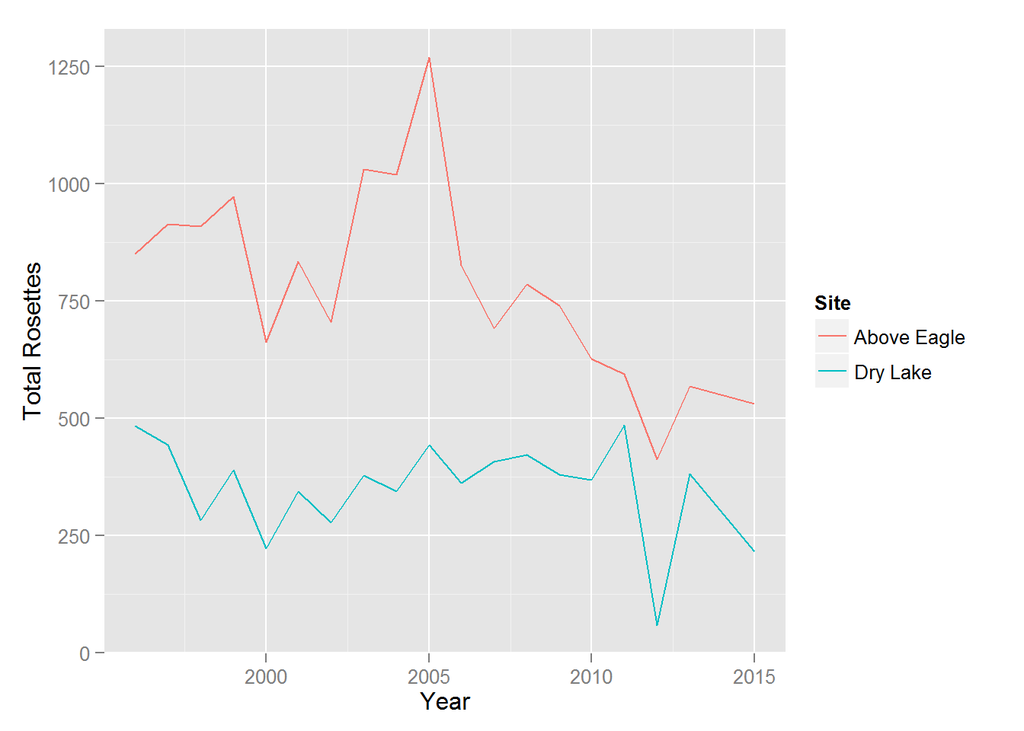

##### Summary data

We want precipitation as the previous 12 months (July-June)

```r
peha_sum <- aggregate(list(TotRos = peha$X.ofRosettes),
                      by=list(Site=peha$Site, Year=peha$Year, Transect=peha$Transect),
                      FUN = sum)

peha_fl.herb <- aggregate(peha[,c(7,9)],
                     by=list(Site=peha$Site, Year=peha$Year, Transect=peha$Transect),
                     FUN = function(x) sum(x)/length(x))

#Label Prev12 as 07 through 12 of the previous year and give it the year for 01-06 (of the previous year (the next year)
peha.c$Month <- as.numeric(peha.c$Month)
peha.c$Year <- as.numeric(peha.c$Year)
peha.c$Prev12 <- peha.c$Year
peha.c[peha.c$Month > 6,8] <- peha.c[peha.c$Month > 6,6]+1


peha_c <- aggregate(peha.c[,2:4], peha.c[,c(5,8)], FUN = function(x) mean(x, na.rm = TRUE))
peha_cprecip <- aggregate(peha.c$Precip, peha.c[,c(5,8)], FUN = sum)

peha_m <- merge(peha_sum, peha_fl.herb, by = c("Site","Year","Transect"))

#in 2012 there were no rosettes found in two transects; 9 and 28
table(peha_m$Transect, peha_m$Year)
```

```
##
##      1996 1997 1998 1999 2000 2001 2002 2003 2004 2005 2006 2007 2008 2009
##   2     1    1    1    1    1    1    1    1    1    1    1    1    1    1
##   3     1    1    1    1    1    1    1    1    1    1    1    1    1    1
##   7     1    1    1    1    1    1    1    1    1    1    1    1    1    1
##   8     1    1    1    1    1    1    1    1    1    1    1    1    1    1
##   9     1    1    1    1    1    1    1    1    1    1    1    1    1    1
##   12    1    1    1    1    1    1    1    1    1    1    1    1    1    1
##   13    1    1    1    1    1    1    1    1    1    1    1    1    1    1
##   17    1    1    1    1    1    1    1    1    1    1    1    1    1    1
##   18    1    1    1    1    1    1    1    1    1    1    1    1    1    1
##   19    1    1    1    1    1    1    1    1    1    1    1    1    1    1
##   22    1    1    1    1    1    1    1    1    1    1    1    1    1    1
##   23    1    1    1    1    1    1    1    1    1    1    1    1    1    1
##   27    1    1    1    1    1    1    1    1    1    1    1    1    1    1
```

[output cut: 29 more lines]

```r
table(peha_m$Transect, peha_m$Site) # DL transect 9 and 28
```

```
##
##      Above Eagle Dry Lake
##   2           19        0
##   3            0       19
##   7           19        0
##   8            0       19
##   9            0       18
##   12          19        0
##   13           0       19
##   17          19        0
##   18           0       19
##   19           0       19
##   22          19        0
##   23           0       19
##   27          19        0
##   28           0       18
##   29           0       19
##   32          19        0
##   33           0       19
##   37          19        0
##   38           0       19
##   39           0       19
```

```r
#Add zero rows for 2012 transects 9 and 28 at Dry Lake
peha_m <- rbind(peha_m, c("Dry Lake",2012,9,0,0,0), c("Dry Lake",2012,28,0,0,0))
peha_m[,c("TotRos","Fl","Br","Year")] <- lapply(peha_m[,c("TotRos","Fl","Br","Year")], as.numeric)

peha_all <- merge(peha_m, peha_c, by.x = c("Site","Year"), by.y =c("Site","Prev12"))
table(peha_all$Site,peha_all$Transect)
```

```
##
##               12 13 17 18 19  2 22 23 27 28 29  3 32 33 37 38 39  7  8  9
##   Above Eagle 19  0 19  0  0 19 19  0 19  0  0  0 19  0 19  0  0 19  0  0
##   Dry Lake     0 19  0 19 19  0  0 19  0 19 19 19  0 19  0 19 19  0 19 19
```

summarySE function borrowed from http://www.cookbook-r.com/Manipulating_data/Summarizing_data/

```r
summarySE <- function(data=NULL, measurevar, groupvars=NULL, na.rm=FALSE,
                      conf.interval=.95, .drop=TRUE) {
    library(plyr)

    # New version of length which can handle NA's: if na.rm==T, don't count them
    length2 <- function (x, na.rm=FALSE) {
        if (na.rm) sum(!is.na(x))
        else       length(x)
    }

    # This does the summary. For each group's data frame, return a vector with
    # N, mean, and sd
    datac <- ddply(data, groupvars, .drop=.drop,
      .fun = function(xx, col) {
        c(N    = length2(xx[[col]], na.rm=na.rm),
          mean = mean   (xx[[col]], na.rm=na.rm),
          sd   = sd     (xx[[col]], na.rm=na.rm)
        )
      },
      measurevar
    )

    # Rename the "mean" column
    datac <- rename(datac, c("mean" = measurevar))

    datac$se <- datac$sd / sqrt(datac$N)  # Calculate standard error of the mean

    # Confidence interval multiplier for standard error
    # Calculate t-statistic for confidence interval:
    # e.g., if conf.interval is .95, use .975 (above/below), and use df=N-1
    ciMult <- qt(conf.interval/2 + .5, datac$N-1)
    datac$ci <- datac$se * ciMult

    return(datac)
}
```

Add summary statistics to the peha table

```r
peha_sumSE <- summarySE(peha_all, measurevar="TotRos", groupvars=c("Site","Year"))
peha_sumSEfl <- summarySE(peha_all, measurevar="Fl", groupvars=c("Site","Year"))
peha_sumSEbr <- summarySE(peha_all, measurevar="Br", groupvars=c("Site","Year"))
peha_sumSEprecip <- summarySE(peha.c, measurevar="Precip", groupvars=c("Site","Prev12"))

peha_table1 <- summarySE(peha_all, measurevar="TotRos", groupvars=c("Site"))
```

Add “a)” to each plot

Figure 1a) average rosettes per transect

```
## ymax not defined: adjusting position using y instead
```

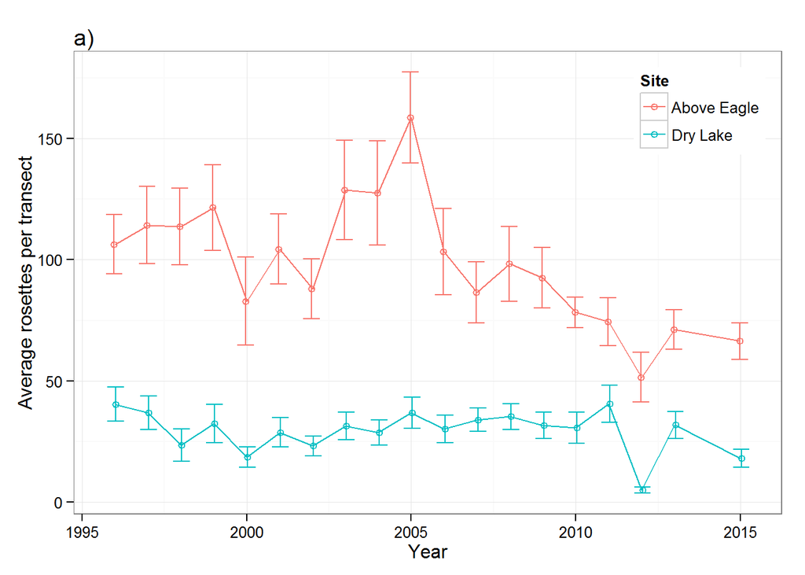

```r
ggplot(peha_sumSE, aes(Year, TotRos, colour=Site)) +
  geom_point(position=position_dodge(0.1), shape=21, fill="white") +
  stat_summary(fun.y = function(x) mean(x, na.rm = TRUE), geom="line") +
  geom_errorbar(aes(ymin=TotRos-se, ymax=TotRos+se),width=1, position = position_dodge(0.1)) +
  theme_bw() +
  ylab("Average rosettes per transect") +
  theme(legend.justification=c(1,1), legend.position=c(1,1)) +
  ggtitle("a)") +
  theme(plot.title=element_text(hjust=0))
```

Figure 1b) percent of indivdiuals that are flowering or fruiting

```
## ymax not defined: adjusting position using y instead
```

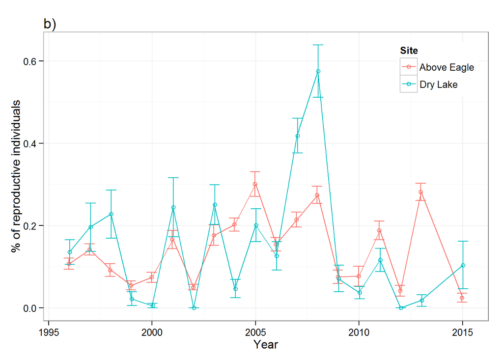

```r
ggplot(peha_sumSEfl, aes(Year, Fl, colour=Site)) +
  geom_point(position=position_dodge(0.1), shape=21, fill="white") +
  stat_summary(fun.y = function(x) mean(x, na.rm = TRUE), geom="line") +
  geom_errorbar(aes(ymin=Fl-se, ymax=Fl+se),width=1, position = position_dodge(0.1)) +
  theme_bw() +
  ylab("% of reproductive individuals") +
  theme(legend.justification=c(1,1), legend.position=c(1,1))+
  ggtitle("b)") +
  theme(plot.title=element_text(hjust=0))
```

Figure 1c) percent of indivdiuals with herbivory

```
## ymax not defined: adjusting position using y instead
```

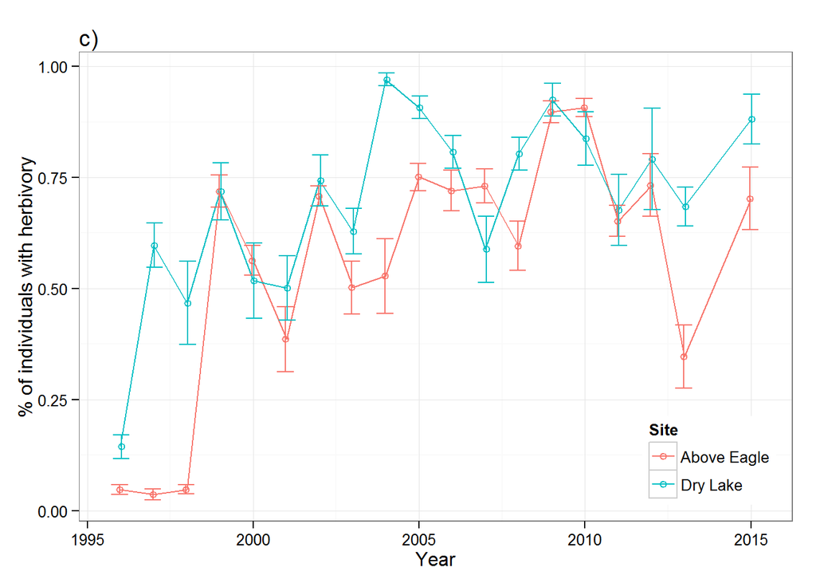

```r
ggplot(peha_sumSEbr, aes(Year, Br, colour=Site)) +
  geom_point(position=position_dodge(0.1), shape=21, fill="white") +
  stat_summary(fun.y = function(x) mean(x, na.rm = TRUE), geom="line") +
  geom_errorbar(aes(ymin=Br-se, ymax=Br+se),width=1, position = position_dodge(0.1)) +
  theme_bw() +
  ylab("% of individuals with herbivory") +
  theme(legend.justification=c(1,0), legend.position=c(1,0)) +
  ggtitle("c)") +
  theme(plot.title=element_text(hjust=0))
```

Average precipitation by month

```
## ymax not defined: adjusting position using y instead
```

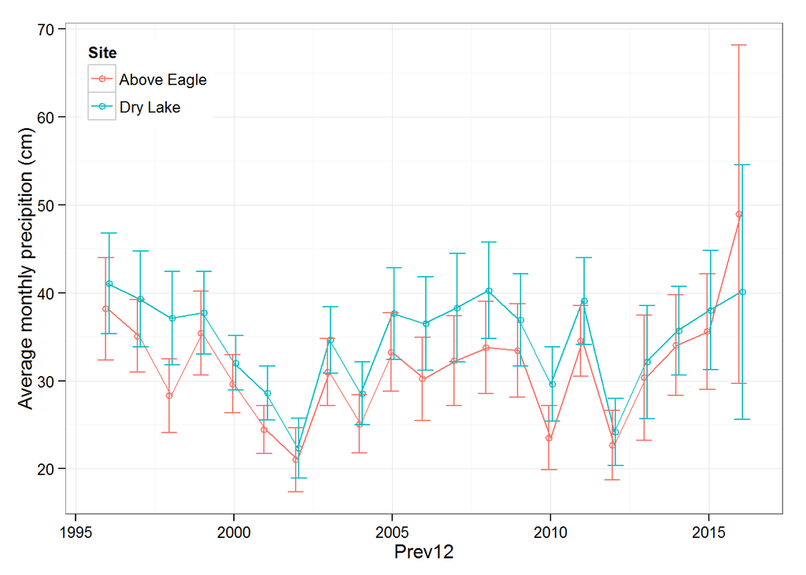

```r
ggplot(peha_sumSEprecip, aes(Prev12, Precip, colour=Site)) +
  geom_point(position=position_dodge(0.2), shape=21, fill="white") +
  stat_summary(fun.y = function(x) mean(x, na.rm = TRUE), geom="line") +
  geom_errorbar(aes(ymin=Precip-se, ymax=Precip+se),width=1, position = position_dodge(0.2)) +
  theme_bw() +
  ylab("Average monthly precipition (cm)") +
  theme(legend.justification=c(0,1), legend.position=c(0,1))
```

Figure 1d) annual precipitation (mm) from the previous 12 months (July-June).

```
## ymax not defined: adjusting position using y instead
```

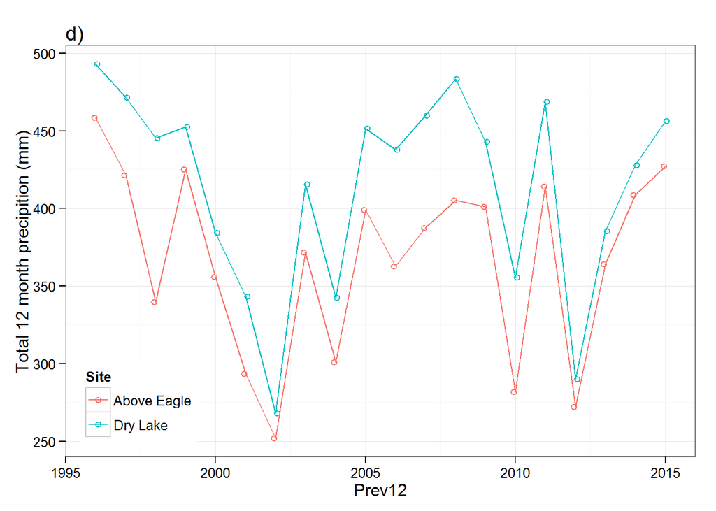

```r
ggplot(subset(peha_cprecip, Prev12 < 2016), aes(Prev12, x, colour=Site)) +
  geom_point(position=position_dodge(0.2), shape=21, fill="white") +
  stat_summary(fun.y = function(x) mean(x, na.rm = TRUE), geom="line") +
  theme_bw() +
  ylab("Total 12 month precipition (mm)") +
  theme(legend.justification=c(0,0), legend.position=c(0,0))  +
  ggtitle("d)") +
  theme(plot.title=element_text(hjust=0))
```

Seaonal climate means  
fall- July:Sept (7-9)  
winter- Oct:Dec (10-12)  
spring- Jan:March (1-3)  
summer- April:June (4-6)

```r
peha.c$season <- "fall"
peha.c[peha.c$Month>9 & peha.c$Month<13,"season"] <- "winter"
peha.c[peha.c$Month>0 & peha.c$Month<4,"season"] <- "spring"
peha.c[peha.c$Month>3 & peha.c$Month<7,"season"] <- "summer"

peha.c.summary <- aggregate(peha.c[,2:4], peha.c[,c("Site","Prev12","season")],
                            FUN = function(x) mean(x, na.rm = TRUE))
```

#### Precip in Table 1

```r
summarySE(peha.c.summary, measurevar="Precip", groupvars=c("Site"))
```

```
##          Site  N   Precip       sd       se       ci
## 1 Above Eagle 81 30.82329 10.51422 1.168246 2.324884
## 2    Dry Lake 81 34.55420 10.22254 1.135838 2.260390
```

Merge summary data with precipition data

```r
peha.1 <- merge(peha_all, peha.c.summary, by.x=c("Site","Year"), by.y=c("Site","Prev12"))
```

Need to fix CountPVA to spit out one data.frame and necessitate assigning it to something  
http://www.montana.edu/screel/Webpages/conservation%20biology/BIOL%20521%20count%20based%20PVA%20grizzly%20data.R

CountPVA produces a list of two data frames, PVA and LM. PVA has the annual log growth rates and LM has the results of the linear model from Morris and Doak Population Viability Analysis

```r
load(path.expand("Q:/Research/Stats & Software/R CODE/Functions/CountPVAFunction.R"))
```

```r
peha_count <- aggregate(list(TotRos = peha$X.ofRosettes),
                      by=list(Site=peha$Site, Year=peha$Year),
                      FUN = sum)

DL.list <- CountPVA(peha_count[peha_count$Site=="Dry Lake","Year"],
         peha_count[peha_count$Site=="Dry Lake","TotRos"])

AE.list <- CountPVA(peha_count[peha_count$Site=="Above Eagle","Year"],
         peha_count[peha_count$Site=="Above Eagle","TotRos"])
```

Using these count estimates, the population growth rate (λ) at Above Eagle is 0.99 (95% CI: 0.94-1.04) and at Dry Lake is 0.98 (95% CI: 0.84-1.14).

```r
lambda.DL <- DL.list[[2]][nrow(DL.list[[2]]),]
lambda.AE <- AE.list[[2]][nrow(AE.list[[2]]),]
lamDL <- lapply(lambda.DL[,4:6], function(x) exp(x))
lamAE <- lapply(lambda.AE[,4:6], function(x) exp(x))
```

Figure 2. Annual growth rate estimates with 95% confidence intervals for consectutive additional years of demogrphaic study

```
## geom_smooth: method="auto" and size of largest group is <1000, so using loess. Use 'method = x' to change the smoothing method.
```

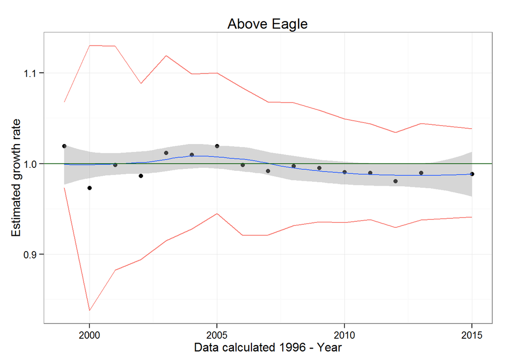

```r
ggplot(AE.list[["LM"]], aes(RangeEnd,exp(fit))) +
  geom_point() +
  stat_smooth() +
  xlab("Data calculated 1996 - Year") +
  ylab("Estimated growth rate") +
  theme_bw() +
  theme(legend.position="none") +
  geom_line(aes(RangeEnd,exp(lwr), colour = "red")) +
  geom_line(aes(RangeEnd,exp(upr),colour = "red")) +
  ggtitle("Above Eagle") +
  geom_hline(aes(yintercept=1), colour = "darkgreen")
```

```
## geom_smooth: method="auto" and size of largest group is <1000, so using loess. Use 'method = x' to change the smoothing method.
```

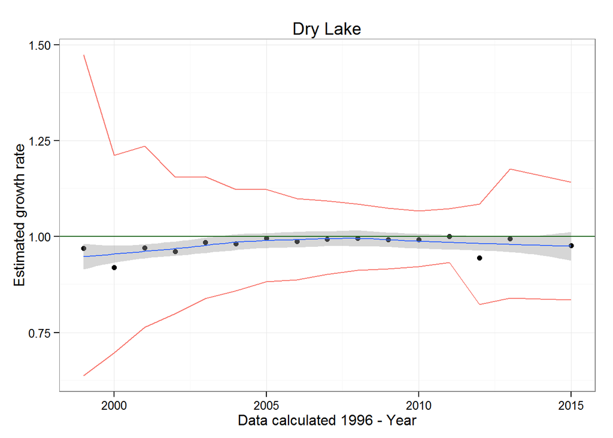

```r
ggplot(DL.list[["LM"]], aes(RangeEnd,exp(fit))) +
  geom_point() +
  stat_smooth() +
  xlab("Data calculated 1996 - Year") +
  ylab("Estimated growth rate") +
  theme_bw() +
  theme(legend.position="none") +
  geom_line(aes(RangeEnd,exp(lwr), colour = "red")) +
  geom_line(aes(RangeEnd,exp(upr),colour = "red"))+
  ggtitle("Dry Lake") +
  geom_hline(aes(yintercept=1), colour = "darkgreen")
```

Need the total precipitation for the previous 12 months (July-June) merged to peha_all. x is sum of precip last 12 months

```r
peha_all_sum <- merge(peha_all, peha_cprecip, by.y = c("Site","Prev12"), by.x = c("Site","Year"))
```

Figure 3. Annual precipitation by (A) number of individuals, (B) percent reproductive and (c) percent herbivory. Black=Above Eagle, Red=Dry Lake

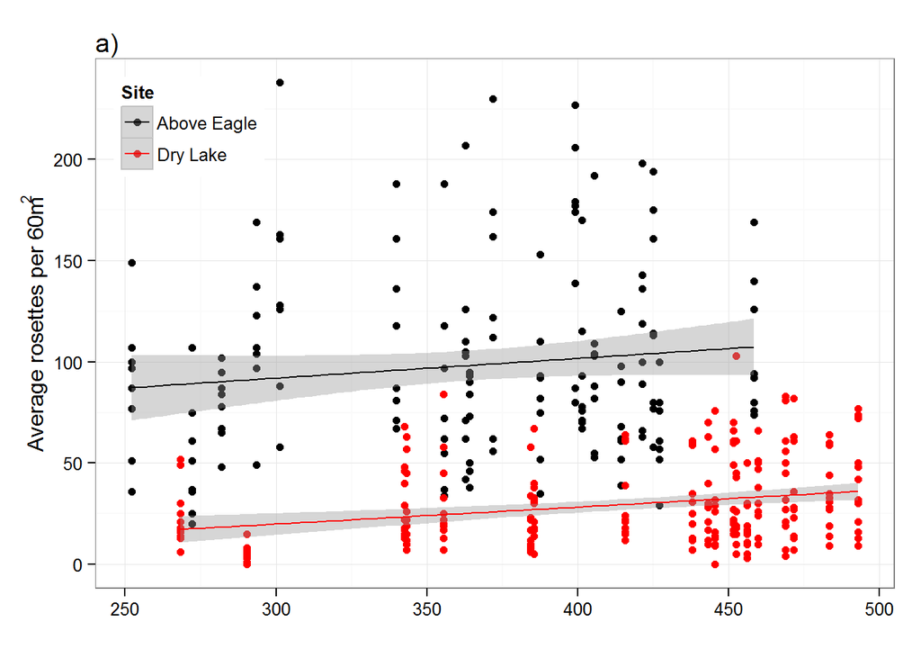

```r
ggplot(peha_all_sum, aes(x, TotRos, colour = Site)) +
  geom_point() +
  geom_smooth(method ="lm") +
  scale_color_manual(values = c("black","red")) +
  theme_bw() +
  xlab("") +
  ylab(expression(paste("Average rosettes per 60m"^2))) +
  theme(legend.justification=c(0,1), legend.position=c(0,1))+
  ggtitle("a)") +
  theme(plot.title=element_text(hjust=0))
```

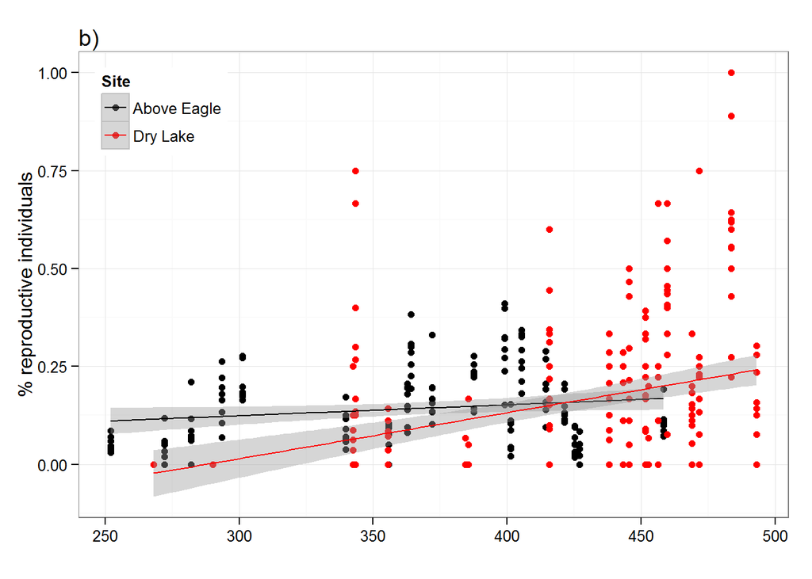

```r
ggplot(peha_all_sum, aes(x, Fl, colour = Site)) +
  geom_point() +
  geom_smooth(method ="lm") +
  scale_color_manual(values = c("black","red")) +
  theme_bw() +
  xlab("") +
  ylab("% reproductive individuals") +
  theme(legend.justification=c(0,1), legend.position=c(0,1))+
  ggtitle("b)") +
  theme(plot.title=element_text(hjust=0))
```

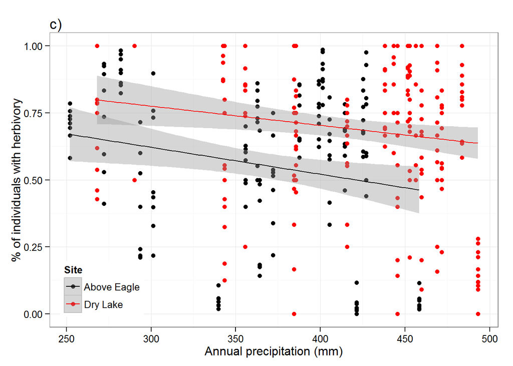

```r
ggplot(peha_all_sum, aes(x, Br, colour = Site)) +
  geom_point() +
  geom_smooth(method ="lm") +
  scale_color_manual(values = c("black","red")) +
  theme_bw() +
  xlab("Annual precipitation (mm)") +
  ylab("% of individuals with herbivory") +
  theme(legend.justification=c(0,0), legend.position=c(0,0))+
  ggtitle("c)") +
  theme(plot.title=element_text(hjust=0))
```

# add a subject unique identifier row

Use for individual ID for repeated measures ANOVA

```r
peha_all_sum$subject <- paste(substr(peha_all_sum$Site,1,1),
                              substr(peha_all_sum$Year,3,4),
                              peha_all_sum$Transect, sep=".")
```

Above Eagle is significantly decreasing while Dry Lake is stable - looks like no, they are both signficantly decreasing?

```r
summary(lm(log(TotRos+1)~Year*Site, data=peha_all_sum))
```

```
##
## Call:
## lm(formula = log(TotRos + 1) ~ Year * Site, data = peha_all_sum)
##
## Residuals:
##     Min      1Q  Median      3Q     Max
## -3.2599 -0.3997  0.0450  0.4447  1.4021
##
## Coefficients:
##                    Estimate Std. Error t value Pr(>|t|)
## (Intercept)        64.53290   20.53334   3.143  0.00181 **
## Year               -0.02995    0.01024  -2.924  0.00366 **
## SiteDry Lake      -26.04023   26.50843  -0.982  0.32657
## Year:SiteDry Lake   0.01231    0.01322   0.931  0.35232
## ---
## Signif. codes:  0 '***' 0.001 '**' 0.01 '*' 0.05 '.' 0.1 ' ' 1
##
## Residual standard error: 0.7029 on 376 degrees of freedom
## Multiple R-squared:  0.4831, Adjusted R-squared:  0.479
## F-statistic: 117.1 on 3 and 376 DF,  p-value: < 2.2e-16
```

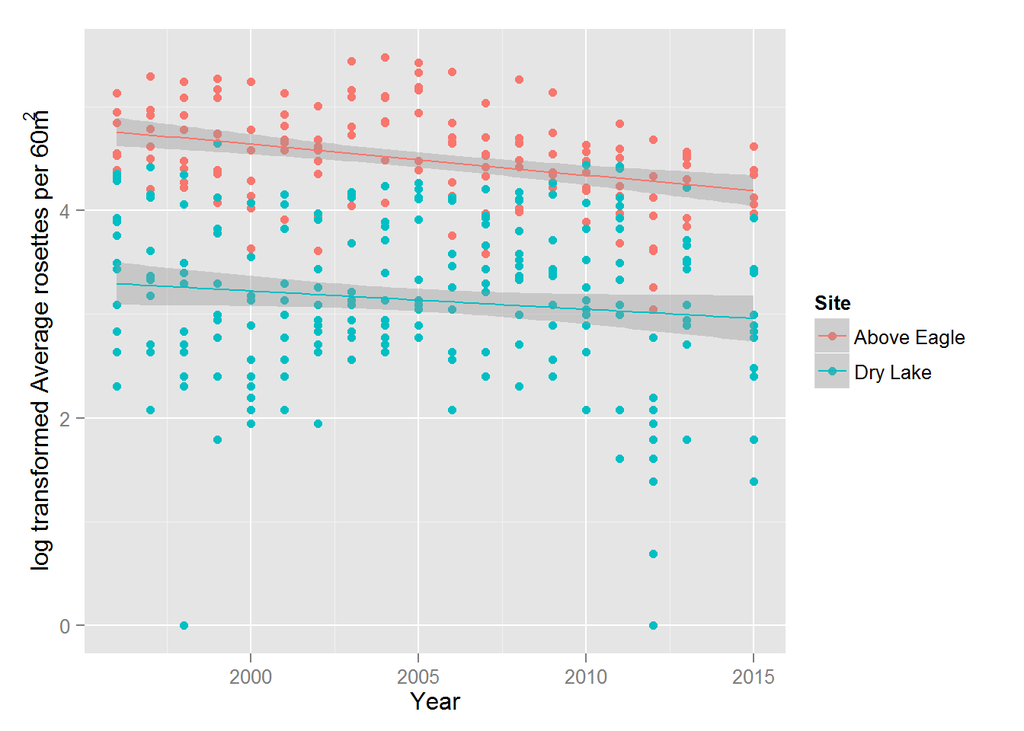

```r
ggplot(peha_all_sum, aes( Year, log(TotRos+1), colour = Site)) +
  geom_point() +
  geom_smooth(method="lm") +
  ylab(expression(paste("log transformed Average rosettes per 60m"^2)))
```

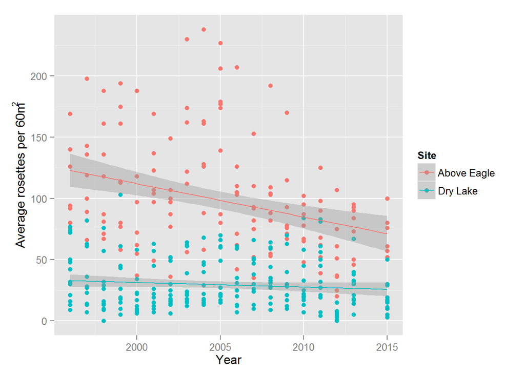

```r
ggplot(peha_all_sum, aes(Year, TotRos, colour = Site)) +
  geom_point() +
  geom_smooth(method="lm") +
  ylab(expression(paste("Average rosettes per 60m"^2)))
```

There is a signficantly greater proportion of reproductive individuals found at Above Eagle than at Dry Lake

```r
peha.aov.fl <-aov(asin(sqrt(Fl))~Year*Site + Error(subject), data=peha_all_sum)
summary(peha.aov.fl)
```

```
##
## Error: subject
##            Df Sum Sq Mean Sq F value  Pr(>F)
## Year        1  0.111  0.1107   1.573 0.21052
## Site        1  0.502  0.5018   7.130 0.00791 **
## Year:Site   1  0.064  0.0644   0.916 0.33921
## Residuals 376 26.463  0.0704
## ---
## Signif. codes:  0 '***' 0.001 '**' 0.01 '*' 0.05 '.' 0.1 ' ' 1
```

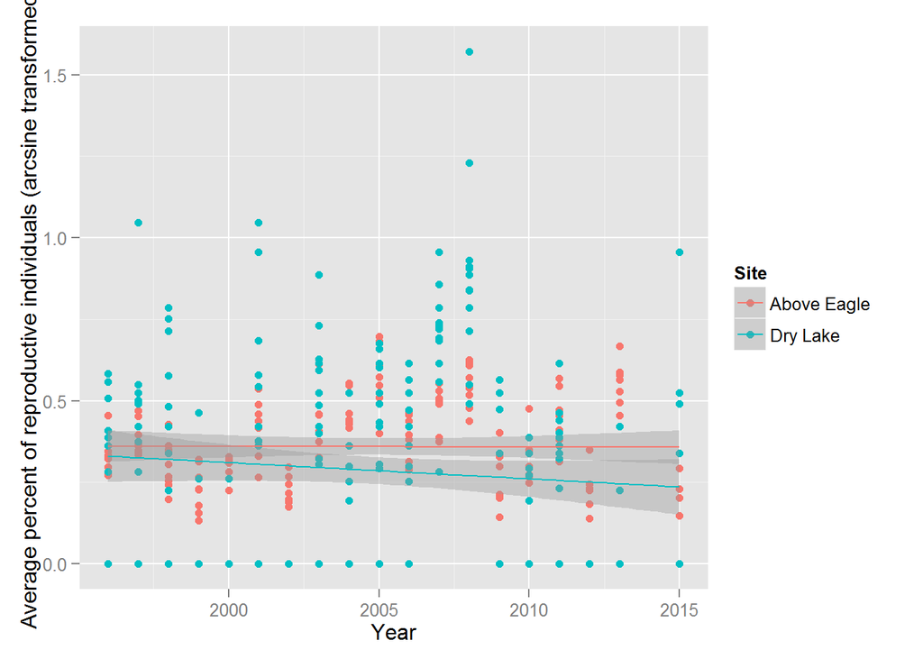

```r
ggplot(peha_all_sum, aes(Year, asin(sqrt(Fl)), colour = Site)) +
  geom_point() +
  geom_smooth(method="lm") +
  ylab("Average percent of reproductive individuals (arcsine transformed)")
```

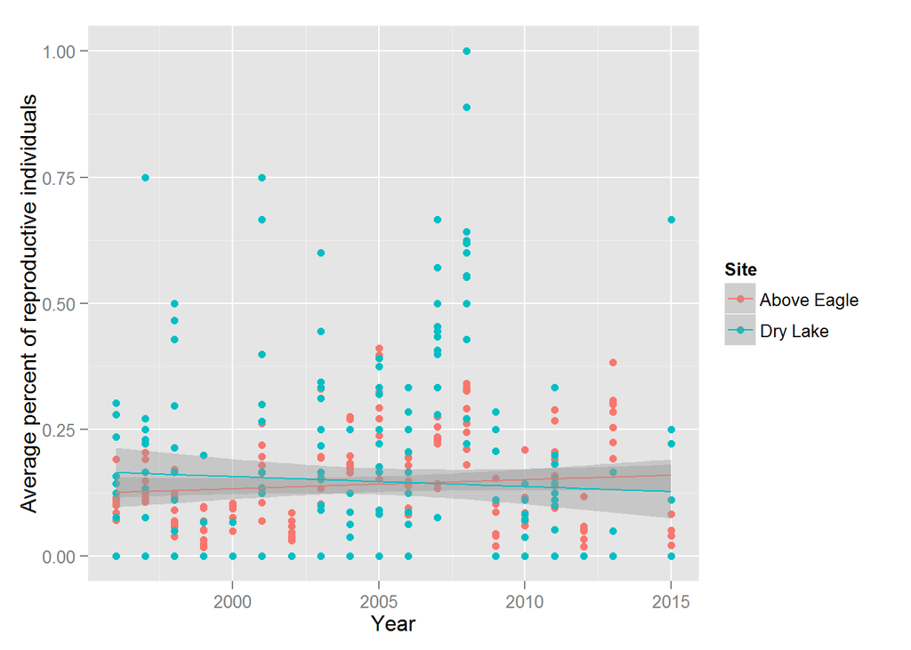

```r
ggplot(peha_all_sum, aes(Year, Fl, colour = Site)) +
  geom_point() +
  geom_smooth(method="lm") +
  ylab("Average percent of reproductive individuals")
```

Significantly more browsing at Dry Lake

```r
peha.aov.Br <-aov(asin(sqrt(Br))~Year*Site + Error(subject), data=peha_all_sum)
summary(peha.aov.Br)
```

```
##
## Error: subject
##            Df Sum Sq Mean Sq F value   Pr(>F)
## Year        1  12.73  12.734  112.74  < 2e-16 ***
## Site        1   4.06   4.055   35.90 4.86e-09 ***
## Year:Site   1   0.09   0.091    0.81    0.369
## Residuals 376  42.47   0.113
## ---
## Signif. codes:  0 '***' 0.001 '**' 0.01 '*' 0.05 '.' 0.1 ' ' 1
```

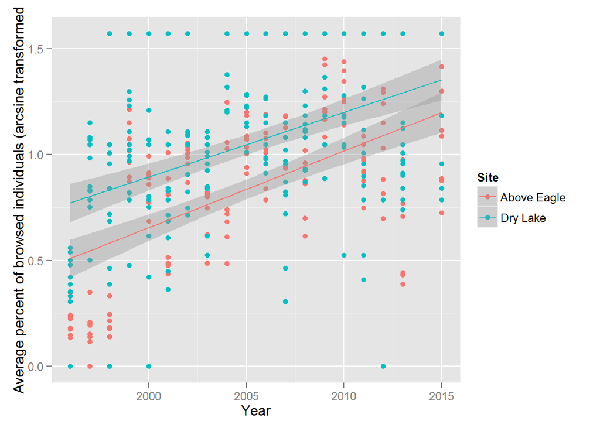

```r
ggplot(peha_all_sum, aes(Year, asin(sqrt(Br)), colour = Site)) +
  geom_point() +
  geom_smooth(method="lm") +
  ylab("Average percent of browsed individuals (arcsine transformed")
```

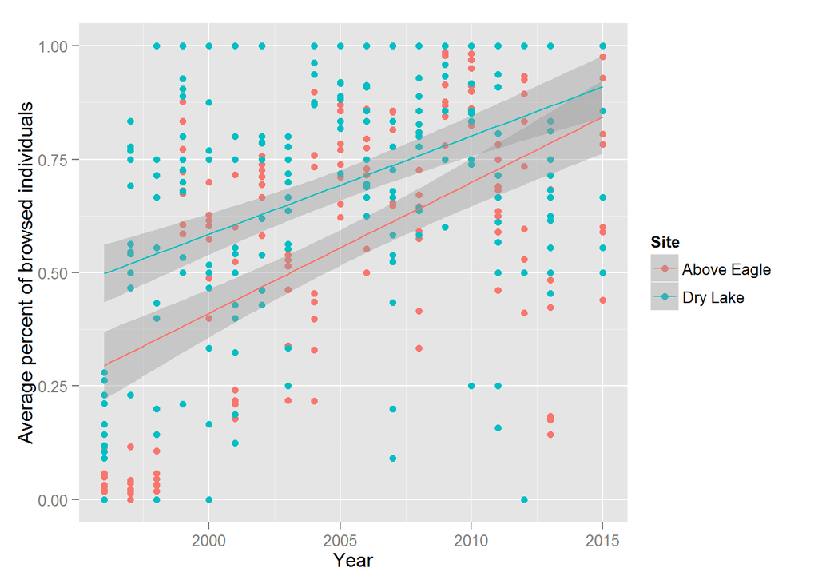

```r
ggplot(peha_all_sum, aes(Year, Br, colour = Site)) +
  geom_point() +
  geom_smooth(method="lm") +
  ylab("Average percent of browsed individuals")
```

## Total rosettes

Rosettes fluctuated over time

```r
peha_totros <- aggregate(list(TotRos = peha$X.ofRosettes),
                      by=list(Site=peha$Site, Year=peha$Year),
                      FUN = sum)


max <- aggregate(TotRos ~ Site, peha_totros, FUN = function(x) max(x))
merge(max,peha_totros)
```

```
##          Site TotRos Year
## 1 Above Eagle   1269 2005
## 2    Dry Lake    486 2011
```

```r
min <- aggregate(TotRos ~ Site, peha_totros, function(x) min(x))
merge(min,peha_totros)
```

```
##          Site TotRos Year
## 1 Above Eagle    412 2012
## 2    Dry Lake     59 2012
```

```r
peha_sumSE[which.max(peha_sumSE$TotRos),]
```

```
##           Site Year N  TotRos       sd       se      ci
## 10 Above Eagle 2005 8 158.625 52.92296 18.71109 44.2447
```

```r
peha_sumSE[which.min(peha_sumSE$TotRos),]
```

```
##        Site Year  N   TotRos       sd       se       ci
## 36 Dry Lake 2012 12 4.916667 4.100074 1.183589 2.605063
```

```r
#Average rosettes
lapply(split(peha_sumSE, peha_sumSE$Site), function(x) {
  rbind(max = x[which.max(x$TotRos),],min = x[which.min(x$TotRos),])
})
```

```
## $`Above Eagle`
##            Site Year N  TotRos       sd       se       ci
## max Above Eagle 2005 8 158.625 52.92296 18.71109 44.24470
## min Above Eagle 2012 8  51.500 28.95316 10.23649 24.20545
##
## $`Dry Lake`
##         Site Year  N    TotRos        sd       se        ci
## max Dry Lake 2011 12 40.500000 26.575792 7.671770 16.885453
## min Dry Lake 2012 12  4.916667  4.100074 1.183589  2.605063
```

# Percent Herbivory - t.tests

T-test between years of browsing

```r
dl <- subset(peha_all_sum, Site == "Dry Lake")
ae <- subset(peha_all_sum, Site == "Above Eagle")
yrs <- unique(peha_all_sum$Year)
#Dry Lake
t.listdl <- vector("list", length(yrs)-1)
names(t.listdl) <- c(paste(yrs[-length(yrs)],yrs[-1], sep = "."))
for(yr in 1:(length(yrs)-1)){
  t.listdl[[yr]] <- t.test(Br~Year,
                        data = subset(dl, Year == yrs[yr] | Year == yrs[yr+1]), paired = TRUE)
}

t.listdl
```

```
## $`1996.1997`
##
##  Paired t-test
##
## data:  Br by Year
## t = -7.5465, df = 11, p-value = 1.133e-05
## alternative hypothesis: true difference in means is not equal to 0
## 95 percent confidence interval:
##  -0.5856865 -0.3211914
## sample estimates:
## mean of the differences
##               -0.453439
##
##
## $`1997.1998`
##
##  Paired t-test
##
## data:  Br by Year
## t = 0.94159, df = 11, p-value = 0.3666
## alternative hypothesis: true difference in means is not equal to 0
## 95 percent confidence interval:
##  -0.1736453  0.4332968
## sample estimates:
## mean of the differences
##               0.1298258
##
##
## $`1998.1999`
##
##  Paired t-test
##
## data:  Br by Year
## t = -2.2826, df = 11, p-value = 0.04334
## alternative hypothesis: true difference in means is not equal to 0
## 95 percent confidence interval:
##  -0.492741936 -0.008967795
## sample estimates:
## mean of the differences
##              -0.2508549
```

[output cut: 195 more lines]

```
##               0.1075759
##
##
## $`2013.2015`
##
##  Paired t-test
##
## data:  Br by Year
## t = -2.5617, df = 11, p-value = 0.02644
## alternative hypothesis: true difference in means is not equal to 0
## 95 percent confidence interval:
##  -0.36723261 -0.02781332
## sample estimates:
## mean of the differences
##               -0.197523
```

```r
results.dl <- data.frame(sapply(t.listdl, "[", c("p.value","statistic","parameter")))
names(results.dl) <- c(paste(yrs[-length(yrs)],yrs[-1], sep = "."))
results.dl
```

```
##              1996.1997 1997.1998  1998.1999  1999.2000 2000.2001
## p.value   1.132604e-05 0.3666229 0.04333885 0.03847566 0.8645693
## statistic    -7.546546 0.9415877  -2.282585   2.350171 0.1745957
## parameter           11        11         11         11        11
##            2001.2002  2002.2003    2003.2004 2004.2005  2005.2006
## p.value   0.03260238 0.07913593 1.454916e-05  0.101061 0.05406739
## statistic  -2.443799   1.934817    -7.346375  1.789553   2.156128
## parameter         11         11           11        11         11
##             2006.2007 2007.2008  2008.2009 2009.2010 2010.2011  2011.2012
## p.value   0.009997872 0.0184363 0.01855618 0.2763828 0.1727758  0.4957416
## statistic    3.105926 -2.763615  -2.759991  1.145323  1.458063 -0.7045418
## parameter          11        11         11        11        11         11
##           2012.2013  2013.2015
## p.value    0.352347 0.02643846
## statistic 0.9711438  -2.561699
## parameter        11         11
```

```r
#Above Eagle
t.listae <- vector("list", length(yrs)-1)
for(yr in 1:(length(yrs)-1)){
  t.listae[[yr]] <- t.test(Br~Year,
                        data = subset(ae, Year == yrs[yr] | Year == yrs[yr+1]), paired = TRUE)
}

t.listae
```

```
## [[1]]
##
##  Paired t-test
##
## data:  Br by Year
## t = 0.68486, df = 7, p-value = 0.5155
## alternative hypothesis: true difference in means is not equal to 0
## 95 percent confidence interval:
##  -0.02578435  0.04680938
## sample estimates:
## mean of the differences
##              0.01051251
##
##
## [[2]]
##
##  Paired t-test
##
## data:  Br by Year
## t = -0.83597, df = 7, p-value = 0.4308
## alternative hypothesis: true difference in means is not equal to 0
## 95 percent confidence interval:
##  -0.04362525  0.02083620
## sample estimates:
## mean of the differences
##             -0.01139452
##
##
## [[3]]
##
##  Paired t-test
##
## data:  Br by Year
## t = -18.24, df = 7, p-value = 3.685e-07
## alternative hypothesis: true difference in means is not equal to 0
## 95 percent confidence interval:
##  -0.7582673 -0.5842283
## sample estimates:
## mean of the differences
##              -0.6712478
```

[output cut: 195 more lines]

```
##               0.3856076
##
##
## [[18]]
##
##  Paired t-test
##
## data:  Br by Year
## t = -3.6081, df = 7, p-value = 0.008646
## alternative hypothesis: true difference in means is not equal to 0
## 95 percent confidence interval:
##  -0.5894153 -0.1227103
## sample estimates:
## mean of the differences
##              -0.3560628
```

```r
results.ae <- data.frame(sapply(t.listae, "[", c("p.value","statistic","parameter")))
names(results.ae) <- c(paste(yrs[-length(yrs)],yrs[-1], sep = "."))
results.ae
```

```
##           1996.1997  1997.1998    1998.1999  1999.2000  2000.2001
## p.value   0.5154633  0.4307817 3.684994e-07 0.02942392 0.03888897
## statistic 0.6848565 -0.8359653    -18.24016   2.727992   2.536028
## parameter         7          7            7          7          7
##             2001.2002  2002.2003  2003.2004  2004.2005 2005.2006
## p.value   0.004240153 0.01769986  0.6715858 0.01736227 0.6192944
## statistic   -4.160303   3.084632 -0.4423429  -3.098356 0.5197043
## parameter           7          7          7          7         7
##            2006.2007 2007.2008    2008.2009 2009.2010    2010.2011
## p.value    0.8439564 0.1532538 0.0008314153 0.7663075 3.524613e-05
## statistic -0.2042675  1.601709    -5.582077 -0.309011     9.267426
## parameter          7         7            7         7            7
##           2011.2012    2012.2013   2013.2015
## p.value   0.2831899 0.0008880935 0.008646234
## statistic -1.162337     5.519429   -3.608082
## parameter         7            7           7
```